# ROH Island Simulation Results for the Labrador Retriever Dataset

Markers with MAF < 0.01 were pruned before computing Expected Heterozygosity ($H_{e}$)

2025-02-27

## Simulation Settings

### General Simulation Settings:

- **Number of Simulated Technical Replicates**: 50
- **New Random Mutations Added to Offspring**: TRUE
- **Reference Population for SNP-chip**: last_breed_formation_generation

### Population History Parameters:

- **Inbred Ancestral Population**: FALSE
- **$N_{e}$ Burn-in Population**: 3185 Individuals
- **Bottleneck Scenario**:
  - **Population Size ($N$)**: 5 Individuals
  - **Duration of Bottleneck Scenario**: 1 Generation(s)
- **Breed Formation**:
  - **Population Size ($N$)**: 330 Individuals
  - **Duration of Breed Formation Scenario**: 110 Generation(s)

### Selection Model Settings:

- **Hard Sweep Scenario** *(Simulate_Hard_Sweep = TRUE)*: In the simulated selection scenario, the causative variant was drawn from the set of alleles present in the post-bottleneck generation that had exactly one allele copy in the population.
- **Frequency Threshold for Fixation of the Allele of the Causative Variant:** 0.99

# 1: Causative Variant (Selection Models)

This section presents the simulation results for the simulated selection models. The models simulate selection on a causative variant under varying selection pressures (selection coefficient values). These results serve as a reference for estimating the selection coefficient of an identified candidate region for selection in the empirical dataset.

## 1.1: Variant Fixation

### 1.1.3: Variant Fixation Summary

Summary of the (near) complete sweeps of the causative variant for the different selection models. The summarizing table below presents the following:

- **Column 1** shows the selection coefficient of the selection model.
- **Column 2** shows the fixation probability, i.e., the likelihood of a randomly selected causative variant to reach fixation at the predefined fixation threshold (0.99) during a simulation run.
- **Columns 3-5** display fixation time statistics for these conditional simulations regarding the average, minimum and maximum number of generations required for fixation in the forward-in-time simulations.

The table is sorted in ascending order by selection coefficient.

[1] “C:/Users/jonat/GitHub/roh-island-simulation/results_chr1_3185_Ne_50TC/Pipeline_results/Causative_variant_Fixation_summary.txt”

| Selection_coefficient | Fixation_probability | Avg_Fixation_time | Min_fixation_time | Max_fixation_time |
| --- | --- | --- | --- | --- |
| s=0.075 | 2.3 | 80 | 56 | 97 |
| s=0.1 | 16.7 | 73 | 59 | 91 |
| s=0.125 | 45.9 | 71 | 48 | 92 |
| s=0.15 | 83.3 | 62 | 42 | 84 |
| s=0.2 | 98.0 | 48 | 38 | 70 |
| s=0.3 | 100.0 | 35 | 28 | 46 |
| s=0.4 | 100.0 | 27 | 21 | 36 |
| s=0.5 | 100.0 | 23 | 19 | 30 |
| s=0.6 | 100.0 | 20 | 15 | 22 |
| s=0.7 | 100.0 | 18 | 15 | 21 |
| s=0.8 | 100.0 | 16 | 12 | 19 |

## 1.2: Causative Variant Windows

This section presents the *causative variant window* for each selection model. This window is initially defined by a subwindow consisting of a 100 kbp region centered around the causative variant (referred to as the *Original 100 kbp Causative Variant Subwindow*), where the average ROH frequency of this subwindow is referred to as the *initial threshold*. The window then expands upstream and downstream until the ROH frequency in both directions drops more than 10 percentage points below the *initial threshold*. In other words, this window captures the region impacted by the causative variant under selection and is designed to mimic the characteristics of ROH hotspot regions.

### 1.2.3: ROH Frequency

To see ROH-frequency plots of the created Causative Variant Windows, uncomment the block of code between “Start plot code” and “End plot code” and then rerun the script.

### 1.2.4: Expected Heterozygosity ($H_{e}$) - Causative Variant Windows

### 1.2.5: Causative Variant Windows - Summary

Summary of causative variant windows from the simulated selection scenarios, presenting averages and confidence intervals (CI) for window length, ROH frequency and expected heterozygosity $H_{e}$. The table also includes minimum and maximum ranges of ROH frequency values and shows the average ROH frequency and its CI for the *Original 100 kbp Causative Variant Subwindow*. The table is sorted in ascending order by selection coefficient.

[1] “C:/Users/jonat/GitHub/roh-island-simulation/results_chr1_3185_Ne_50TC/Pipeline_results/Causative_variant_windows_summary.txt”

| Sel.coeff | Length_Mb | Length_lower_CI | Length_Upper_CI | ROH_freq | ROH_freq_lower_CI | ROH_freq_upper_CI | Min_freq | Max_freq | variant_subwindow_freq | variant_subwindow_freq_lower_CI | variant_subwindow_freq_upper_CI | Avg_H_e | H_e_lower_CI | H_e_upper_CI |
| --- | --- | --- | --- | --- | --- | --- | --- | --- | --- | --- | --- | --- | --- | --- |
| s=0.075 | 1.04 | 0.92 | 1.16 | 77.1 | 72.7 | 81.5 | 30.9 | 100 | 79.3 | 75.0 | 83.6 | 0.112 | 0.091 | 0.133 |
| s=0.1 | 1.11 | 0.96 | 1.26 | 77.8 | 73.1 | 82.4 | 27.6 | 100 | 79.2 | 74.7 | 83.7 | 0.118 | 0.094 | 0.141 |
| s=0.125 | 1.11 | 0.96 | 1.26 | 82.2 | 77.2 | 87.3 | 24.8 | 100 | 83.9 | 78.9 | 88.8 | 0.100 | 0.076 | 0.124 |
| s=0.15 | 1.26 | 1.10 | 1.42 | 87.0 | 83.4 | 90.5 | 50.6 | 100 | 88.6 | 85.1 | 92.1 | 0.092 | 0.068 | 0.115 |
| s=0.2 | 1.41 | 1.17 | 1.64 | 87.3 | 83.8 | 90.7 | 49.1 | 100 | 88.9 | 85.6 | 92.3 | 0.093 | 0.072 | 0.114 |
| s=0.3 | 1.58 | 1.34 | 1.82 | 93.4 | 91.3 | 95.5 | 68.8 | 100 | 94.6 | 92.6 | 96.7 | 0.086 | 0.066 | 0.105 |
| s=0.4 | 1.96 | 1.67 | 2.25 | 93.5 | 90.7 | 96.2 | 34.2 | 100 | 94.8 | 92.1 | 97.5 | 0.069 | 0.053 | 0.084 |
| s=0.5 | 2.22 | 1.90 | 2.54 | 97.2 | 96.1 | 98.2 | 80.6 | 100 | 98.4 | 97.4 | 99.5 | 0.084 | 0.058 | 0.110 |
| s=0.6 | 2.06 | 1.79 | 2.33 | 96.2 | 94.4 | 98.0 | 67.9 | 100 | 97.5 | 95.8 | 99.2 | 0.063 | 0.046 | 0.081 |
| s=0.7 | 2.39 | 2.05 | 2.74 | 97.7 | 96.7 | 98.6 | 75.5 | 100 | 98.8 | 97.9 | 99.7 | 0.058 | 0.038 | 0.078 |
| s=0.8 | 2.58 | 2.19 | 2.96 | 96.1 | 93.3 | 98.9 | 29.4 | 100 | 97.1 | 94.3 | 99.8 | 0.084 | 0.059 | 0.109 |

# 2: ROH Frequency

## 2.1: Autosomal Genomewide ROH Frequencies

## 2.2: ROH Hotspot Threshold Summary

The following table shows a comparison between the empirical ROH hotspot-threshold and each simulation model type. Lower CI and Upper CI correspond to the standard-error based confidence intervals of the ROH hotspot threshold with a confidence level of 95%. [1] “C:/Users/jonat/GitHub/roh-island-simulation/results_chr1_3185_Ne_50TC/Pipeline_results/ROH-hotspot_threshold_comparison.txt”

| Model | Avg_ROH_hotspot_threshold | Lower_CI | Upper_CI |
| --- | --- | --- | --- |
| Neutral | 54.0 | 50.7 | 57.4 |
| Empirical | 55.4 | NA | NA |
| s=0.075 | 71.0 | 68.0 | 74.1 |
| s=0.1 | 72.6 | 68.5 | 76.7 |
| s=0.125 | 75.1 | 70.8 | 79.3 |
| s=0.15 | 79.4 | 75.8 | 83.0 |
| s=0.2 | 83.1 | 79.4 | 86.8 |
| s=0.3 | 89.3 | 86.4 | 92.2 |
| s=0.4 | 92.6 | 90.1 | 95.1 |
| s=0.6 | 95.6 | 93.5 | 97.7 |
| s=0.5 | 96.5 | 94.8 | 98.2 |
| s=0.7 | 96.9 | 95.3 | 98.5 |
| s=0.8 | 98.0 | 96.7 | 99.3 |

# 3: Inbreeding Coefficient ($F_{ROH}$)

In this section, the distribution of the inbreeding coefficient ($F_{ROH}$) is plotted for both the empirical dataset and the simulated models (neutral and selection models). For the simulation models, the distribution reflects the variation in the population average $F_{ROH}$ across all technical replicates.

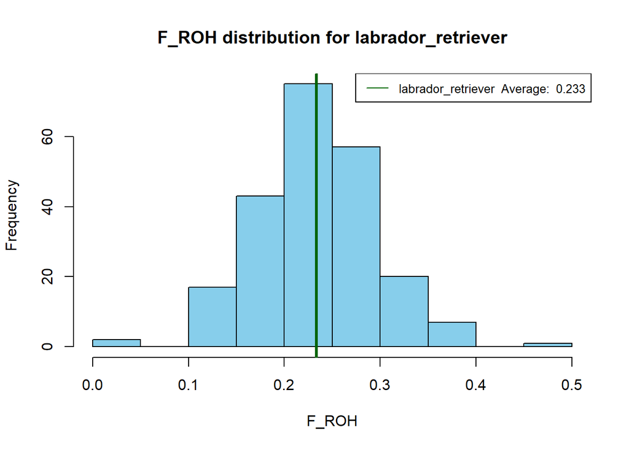

**Overall Average $F_{ROH}$ for labrador_retriever :**

0.2333818

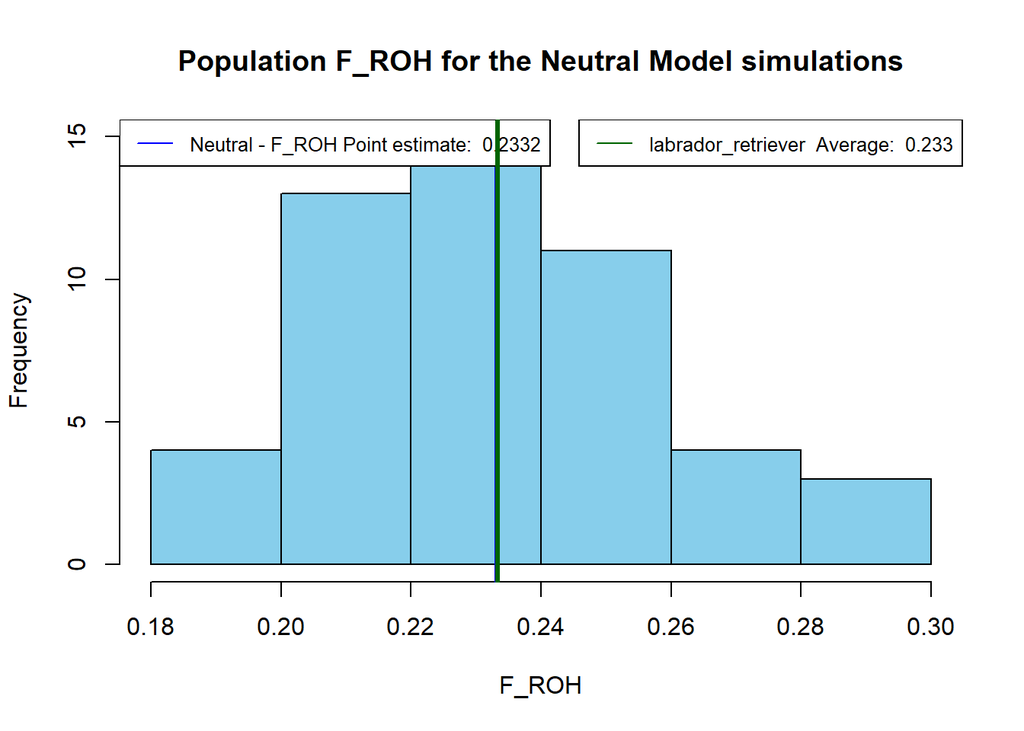

**The point estimate of $F_{ROH}$ across all 50 simulations for the Neutral Model:**

0.2331937

**Standard Error 95% Confidence Interval:**

[ 0.2259777 , 0.2404098 ]

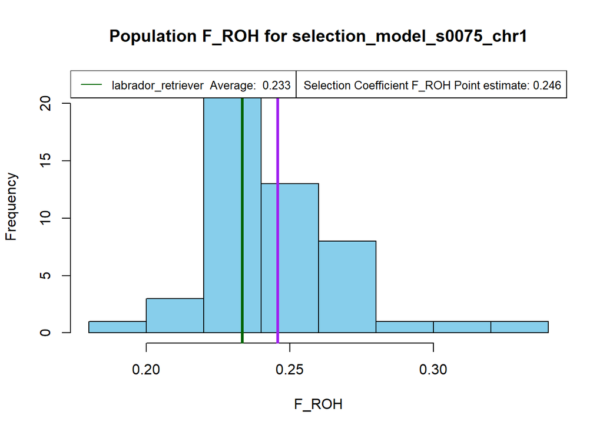

**The point estimate of $F_{ROH}$ across all 50 simulations for selection_model_s0075_chr1 :**

0.2457452

**Standard Error-based 95% Confidence Interval:**

[ 0.2390085 , 0.2524819 ]

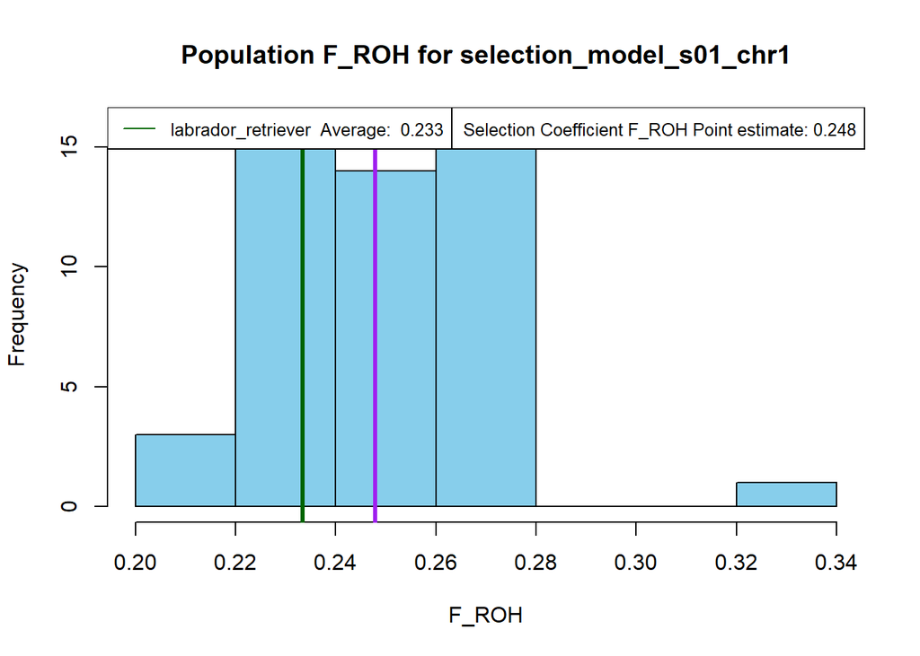

**The point estimate of $F_{ROH}$ across all 50 simulations for selection_model_s01_chr1 :**

0.247888

**Standard Error-based 95% Confidence Interval:**

[ 0.2421127 , 0.2536634 ]

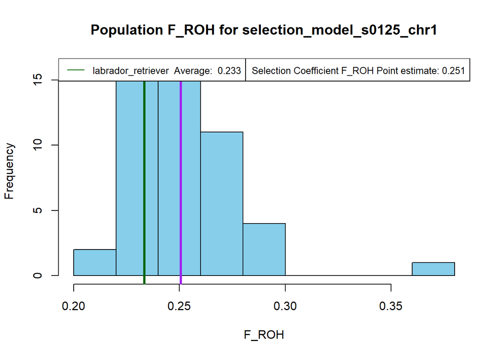

**The point estimate of $F_{ROH}$ across all 50 simulations for selection_model_s0125_chr1 :**

0.2505926

**Standard Error-based 95% Confidence Interval:**

[ 0.2432844 , 0.2579008 ]

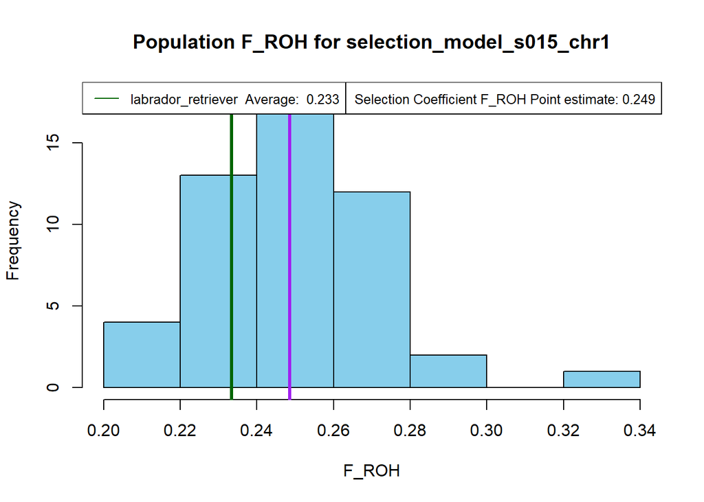

**The point estimate of $F_{ROH}$ across all 50 simulations for selection_model_s015_chr1 :**

0.2485584

**Standard Error-based 95% Confidence Interval:**

[ 0.2425271 , 0.2545897 ]

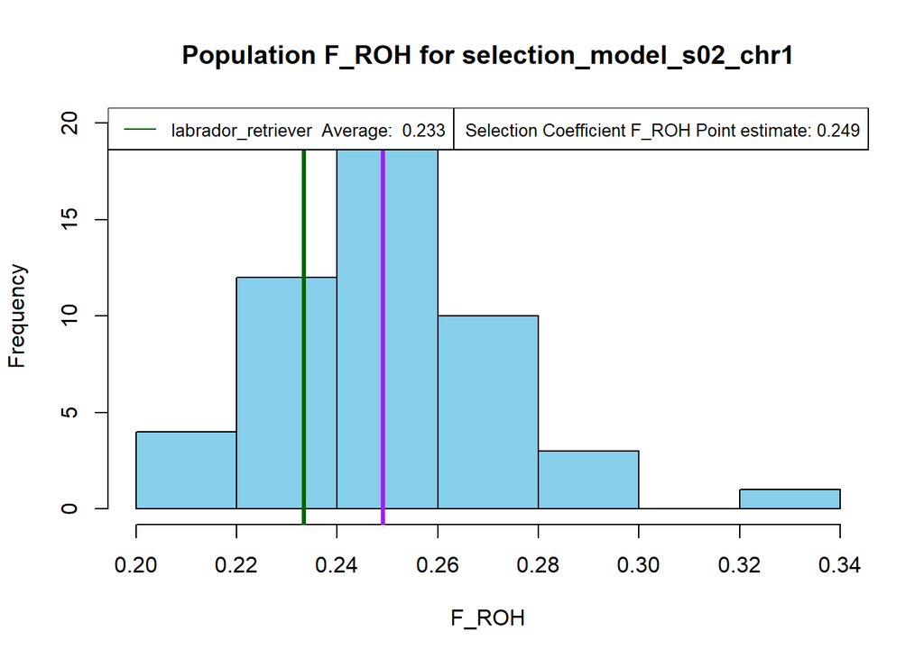

**The point estimate of $F_{ROH}$ across all 50 simulations for selection_model_s02_chr1 :**

0.2491423

**Standard Error-based 95% Confidence Interval:**

[ 0.2431505 , 0.2551341 ]

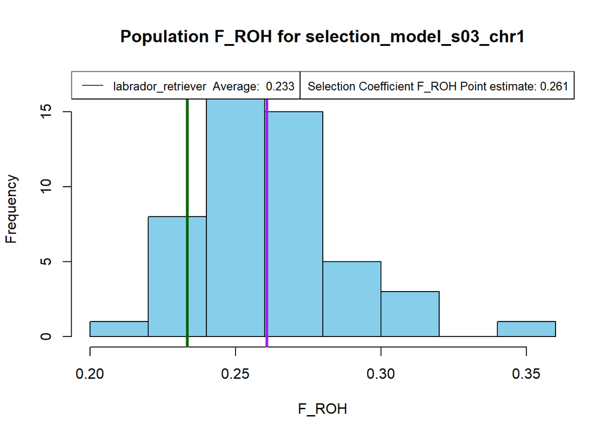

**The point estimate of $F_{ROH}$ across all 50 simulations for selection_model_s03_chr1 :**

0.2607497

**Standard Error-based 95% Confidence Interval:**

[ 0.2539736 , 0.2675258 ]

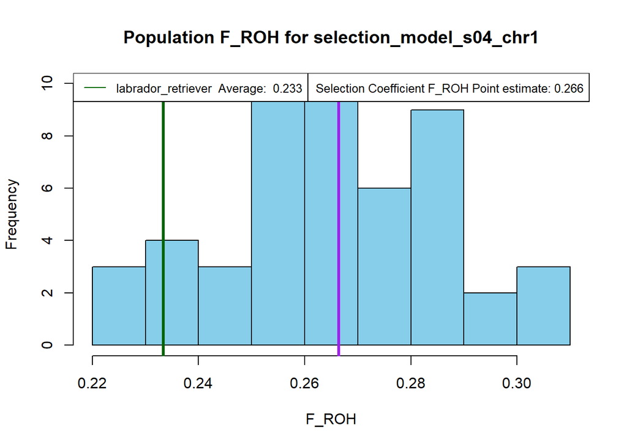

**The point estimate of $F_{ROH}$ across all 50 simulations for selection_model_s04_chr1 :**

0.2664084

**Standard Error-based 95% Confidence Interval:**

[ 0.2605922 , 0.2722246 ]

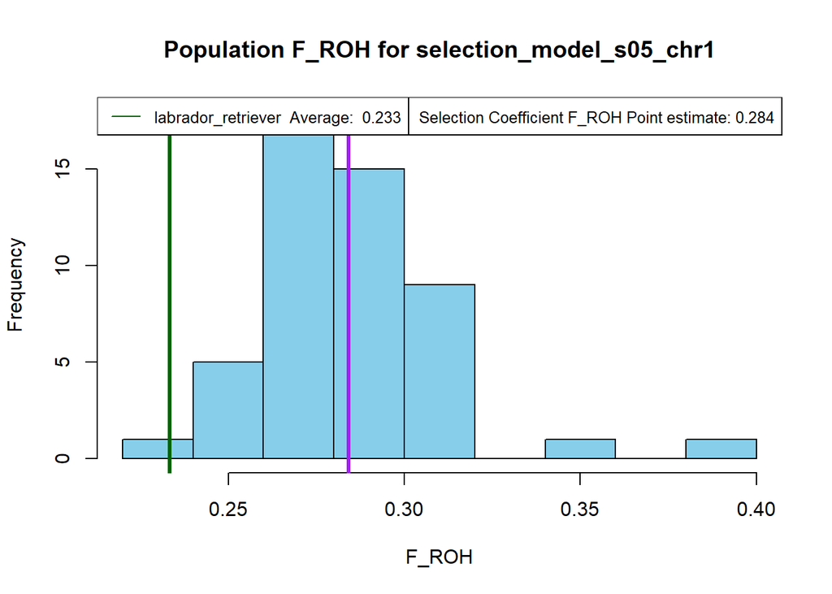

**The point estimate of $F_{ROH}$ across all 50 simulations for selection_model_s05_chr1 :**

0.2841088

**Standard Error-based 95% Confidence Interval:**

[ 0.2769581 , 0.2912594 ]

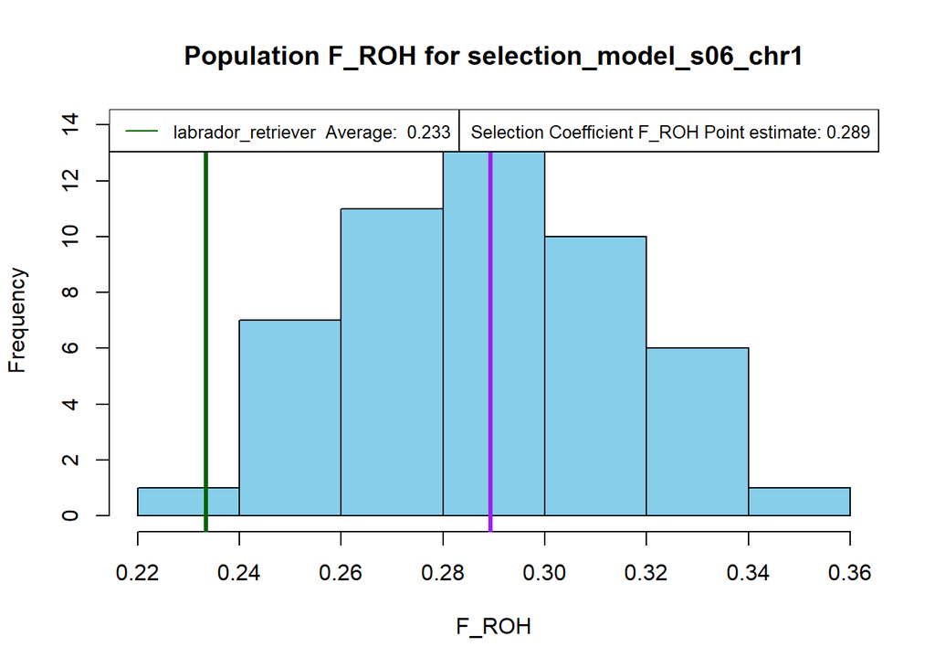

**The point estimate of $F_{ROH}$ across all 50 simulations for selection_model_s06_chr1 :**

0.2892974

**Standard Error-based 95% Confidence Interval:**

[ 0.281786 , 0.2968087 ]

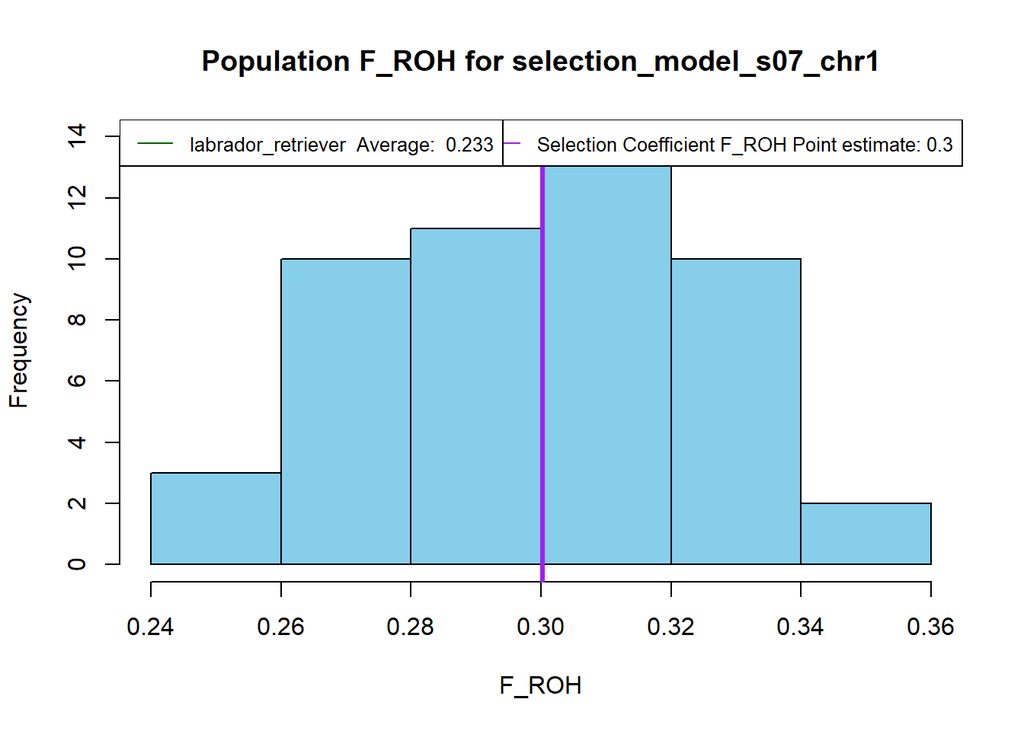

**The point estimate of $F_{ROH}$ across all 50 simulations for selection_model_s07_chr1 :**

0.3002323

**Standard Error-based 95% Confidence Interval:**

[ 0.2930425 , 0.3074221 ]

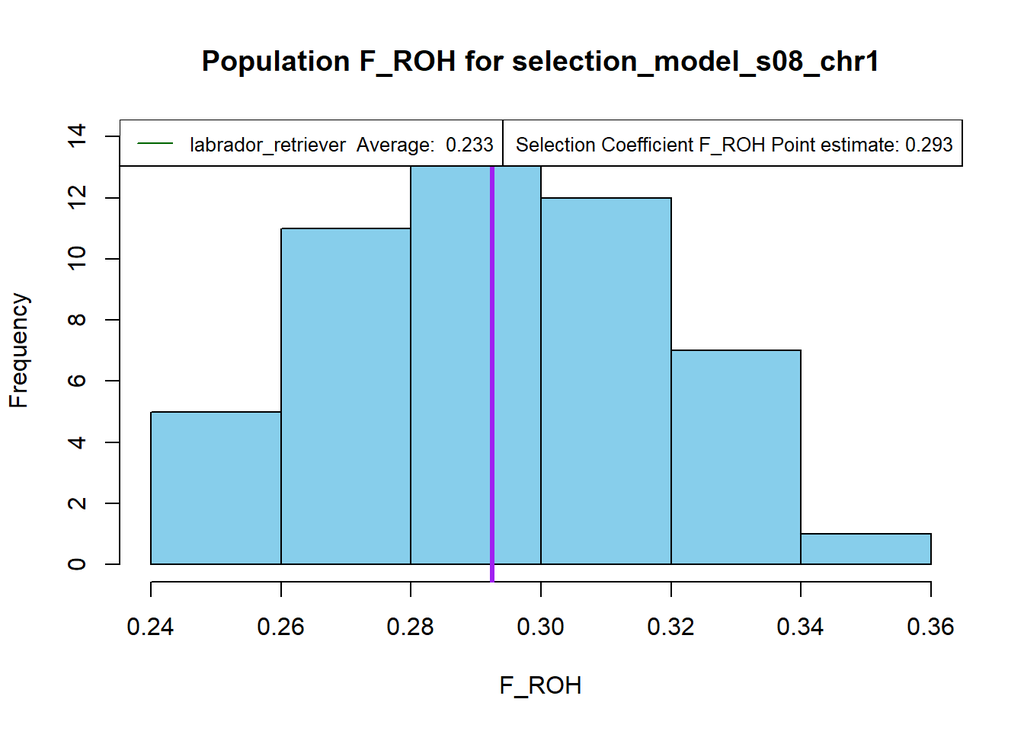

**The point estimate of $F_{ROH}$ across all 50 simulations for selection_model_s08_chr1 :**

0.2925508

**Standard Error-based 95% Confidence Interval:**

[ 0.2855669 , 0.2995347 ]

## 3.4: $F_{ROH}$ Summary

This section presents a comparison of the population average inbreeding coefficient ($F_{ROH}$) between each simulation type and the empirical data. The displayed inbreeding coefficients for the different simulation types represents the point estimate of $F_{ROH}$ across all technical replicates. The Lower CI and Upper CI represent the boundaries of the sample standard-error-based confidence intervals for the population $F_{ROH}$, with a confidence level of 95%.

[1] “C:/Users/jonat/GitHub/roh-island-simulation/results_chr1_3185_Ne_50TC/Pipeline_results/F_ROH_comparison.txt”

| Model | F_ROH | Lower_CI | Upper_CI |
| --- | --- | --- | --- |
| Neutral | 0.233 | 0.226 | 0.240 |
| Empirical | 0.233 | NA | NA |
| s=0.075 | 0.246 | 0.239 | 0.252 |
| s=0.1 | 0.248 | 0.242 | 0.254 |
| s=0.15 | 0.249 | 0.243 | 0.255 |
| s=0.2 | 0.249 | 0.243 | 0.255 |
| s=0.125 | 0.251 | 0.243 | 0.258 |
| s=0.3 | 0.261 | 0.254 | 0.268 |
| s=0.4 | 0.266 | 0.261 | 0.272 |
| s=0.5 | 0.284 | 0.277 | 0.291 |
| s=0.6 | 0.289 | 0.282 | 0.297 |
| s=0.8 | 0.293 | 0.286 | 0.300 |
| s=0.7 | 0.300 | 0.293 | 0.307 |

# 4: Expected Heterozygosity ($H_{e}$)

## 4.4: Genomewide Average $H_{e}$ Summary

This section presents a summary of the mean point estimation of the genome-wide average expected heterozygosity ($H_{e}$), calculated across all 100 kbp binned genomic regions. The Lower CI and Upper CI represent the boundaries of the sample standard-error based confidence intervals for the average $H_{e}$, with a confidence level of 95%.

| Model | H_e | Lower_CI | Upper_CI |
| --- | --- | --- | --- |
| Empirical | 0.316 | NA | NA |
| s=0.8 | 0.320 | 0.318 | 0.322 |
| s=0.7 | 0.321 | 0.318 | 0.323 |
| s=0.5 | 0.322 | 0.319 | 0.324 |
| s=0.4 | 0.324 | 0.322 | 0.325 |
| s=0.6 | 0.324 | 0.321 | 0.327 |
| s=0.2 | 0.326 | 0.324 | 0.328 |
| s=0.3 | 0.326 | 0.323 | 0.328 |
| s=0.15 | 0.327 | 0.325 | 0.329 |
| s=0.1 | 0.328 | 0.326 | 0.330 |
| s=0.075 | 0.329 | 0.327 | 0.331 |
| s=0.125 | 0.329 | 0.327 | 0.331 |
| Neutral | 0.330 | 0.329 | 0.332 |

## 4.5: Genomewide 5th Percentile of Expected Heterozygosity Summary

Summary of the mean point estimation of expected heterozygosity ($H_{e}$) 5th percentile values with standard error-based confidence intervals. “C:/Users/jonat/GitHub/roh-island-simulation/results_chr1_3185_Ne_50TC/Pipeline_results/Expected_Heterozygosity_Summary.txt”

| Model | H_e_5th_percentile | Lower_CI | Upper_CI |
| --- | --- | --- | --- |
| s=0.7 | 0.136 | 0.130 | 0.141 |
| s=0.5 | 0.138 | 0.132 | 0.143 |
| s=0.8 | 0.139 | 0.134 | 0.144 |
| s=0.6 | 0.140 | 0.135 | 0.145 |
| s=0.4 | 0.148 | 0.144 | 0.152 |
| Empirical | 0.151 | NA | NA |
| s=0.3 | 0.153 | 0.149 | 0.157 |
| s=0.2 | 0.157 | 0.154 | 0.160 |
| s=0.125 | 0.158 | 0.154 | 0.161 |
| s=0.15 | 0.158 | 0.154 | 0.162 |
| s=0.075 | 0.160 | 0.156 | 0.164 |
| s=0.1 | 0.160 | 0.156 | 0.164 |
| Neutral | 0.167 | 0.164 | 0.171 |

# 5. OMIA Phenotypes

## 5.1 All Breed-Specific Non-Defect (Non-Disease-Related) Phenotypes

**The following Vertebrate Breed Ontology (VBO) ID(s) were used for associating, or could potentially be associated with the empirical dataset:**

VBO_0200800, Unspecified

**Below are the non-defect phenotypes discovered on OMIA, associated with these VBO IDs.**

These phenotypes include cases where no known links to a specific genomic region or breed have been reported on OMIA so far. Additionally, some phenotypes may have genomic coordinates mapped to a different reference assembly, which could result in misalignment relative to the identified ROH hotspot regions, and thus, may be misclassified as ‘not overlapping with any ROH hotspot region’.

Therefore, these table(s) could serve as a valuable resource for identifying phenotypes that otherwise may have been overlooked due to incomplete genomic mappings or lack of direct breed associations. They offer an opportunity for further investigation, particularly (if applicable) through re-mapping coordinates using a LiftOver process to potentially align them with the discovered ROH hotspot regions.

| CHR | POS1 | POS2 | PHENE | PHENE_CATEGORY | SINGLE_GENE_TRAIT_OR_DISORDER | DISEASE_RELATED | GENE_SYMBOL | GENE_DESCRIPTION | PHENE_URL | GENE_DETAILS_URL | BREEDS |
| --- | --- | --- | --- | --- | --- | --- | --- | --- | --- | --- | --- |
|  |  |  | Behaviour | Behaviour / neurological phene | no | unknown |  |  | https://www.omia.org/OMIA002328/9615/ |  | VBO_0200147, VBO_0200486, VBO_0200546, VBO_0200577, VBO_0200800 |
| X | 61442067 | 61595242 | Modifier of copper toxicosis, ATP7A-related | Homeostasis / metabolism phene | yes | no | ATP7A | ATPase, Cu++ transporting, alpha polypeptide | https://www.omia.org/OMIA002608/9615/ | https://www.omia.org/gene406185/ | VBO_0200800 |
| 20 | 52963476 | 52964967 | Modifier of copper toxicosis, RETN-related | Homeostasis / metabolism phene | yes | no | RETN | resistin | https://www.omia.org/OMIA002609/9615/ | https://www.omia.org/gene388306078/ | VBO_0200800 |

CHR

POS1

POS2

PHENE

PHENE_CATEGORY

SINGLE_GENE_TRAIT_OR_DISORDER

DISEASE_RELATED

GENE_SYMBOL

GENE_DESCRIPTION

PHENE_URL

GENE_DETAILS_URL

BREEDS

1

111058288

111055483

Hyperlipidaemia/atherosclerosis, APOE-related

Homeostasis / metabolism phene

yes

no

APOE

apolipoprotein E

https://www.omia.org/OMIA002063/9615/

https://www.omia.org/gene388244913/

Unspecified

1

24331495

24326030

Reduced hair shedding, MC5R-related

Integument (skin) phene

yes

no

MC5R

melanocortin 5 receptor

https://www.omia.org/OMIA002750/9615/

https://www.omia.org/gene388250420/

Unspecified

3

92125265

92275341

Height, LCORL-associated body-size variation

Growth / size / body region phene

no

no

LCORL

ligand dependent nuclear receptor corepressor-like

https://www.omia.org/OMIA002246/9615/

https://www.omia.org/gene388307121/

Unspecified

5

63923224

63922271

Coat colour, extension

Pigmentation phene

yes

no

MC1R

melanocortin 1 receptor (alpha melanocyte stimulating hormone receptor)

https://www.omia.org/OMIA001199/9615/

https://www.omia.org/gene489652/

Unspecified

5

63923224

63922271

Coat colour, grizzle

Pigmentation phene

yes

no

MC1R

melanocortin 1 receptor (alpha melanocyte stimulating hormone receptor)

https://www.omia.org/OMIA001495/9615/

https://www.omia.org/gene489652/

Unspecified

5

63923224

63922271

Coat colour, melanistic mask

Pigmentation phene

yes

no

MC1R

melanocortin 1 receptor (alpha melanocyte stimulating hormone receptor)

https://www.omia.org/OMIA001590/9615/

https://www.omia.org/gene489652/

Unspecified

9

59449060

59512699

Coat colour, harlequin

Pigmentation phene

yes

no

PSMB7

proteasome subunit beta 7

https://www.omia.org/OMIA001454/9615/

https://www.omia.org/gene25031640/

Unspecified

10

7971606

8151219

Ears, folded (drop vs prick)

Hearing / vestibular / ear phene

unknown

no

MSRB3

methionine sulfoxide reductase B3

https://www.omia.org/OMIA000319/9615/

https://www.omia.org/gene388303816/

Unspecified

10

8459176

8604625

Height, HMGA2-associated body-size variation

Growth / size / body region phene

no

no

HMGA2

high mobility group AT-hook 2

https://www.omia.org/OMIA001968/9615/

https://www.omia.org/gene389077191/

Unspecified

13

9022401

8873544

Furnishings (moustache and eyebrows)

Integument (skin) phene

yes

no

RSPO2

R-spondin 2

https://www.omia.org/OMIA001531/9615/

https://www.omia.org/gene23857650/

Unspecified

15

30311189

30230533

Coat colour, phaeomelanin dilution, KITLG-related

Pigmentation phene

yes

no

KITLG

KIT ligand

https://www.omia.org/OMIA002228/9615/

https://www.omia.org/gene388199034/

Unspecified

16

57081626

57083181

Coat colour, dominant black

Pigmentation phene

yes

no

CBD103

beta-defensin 103

https://www.omia.org/OMIA001416/9615/

https://www.omia.org/gene4236237/

Unspecified

20

22101930

21883312

Coat colour, white spotting

Pigmentation phene

yes

no

MITF

microphthalmia-associated transcription factor

https://www.omia.org/OMIA000214/9615/

https://www.omia.org/gene415126/

Unspecified

20

56514447

56522856

Coat colour, phaeomelanin dilution, MFSD12-related

Pigmentation phene

yes

no

MFSD12

major facilitator superfamily domain containing 12

https://www.omia.org/OMIA002197/9615/

https://www.omia.org/gene388251177/

Unspecified

24

24041356

24084629

Coat colour, agouti

Pigmentation phene

yes

no

ASIP

agouti signaling protein

https://www.omia.org/OMIA000201/9615/

https://www.omia.org/gene492296/

Unspecified

Deficiency of cytosolic arylamine N-acetylation

Normal phene

yes

no

https://www.omia.org/OMIA001587/9615/

Unspecified

Height, IGF2BP2-associated body-size variation

Growth / size / body region phene

no

no

https://www.omia.org/OMIA002921/9615/

Unspecified

Dog allergen

Normal phene

unknown

no

https://www.omia.org/OMIA002799/9615/

Unspecified

Vaccine-induced immune response, variation in

Immune system phene

no

no

https://www.omia.org/OMIA002844/9615/

Unspecified

Woolly hair

Integument (skin) phene

unknown

no

https://www.omia.org/OMIA001256/9615/

Unspecified

Body weight

Growth / size / body region phene

unknown

no

https://www.omia.org/OMIA002077/9615/

Unspecified

Cyclic guanosine monophosphate (cGMP) concentration, reduced

Homeostasis / metabolism phene

unknown

no

https://www.omia.org/OMIA002774/9615/

Unspecified

Adaptation, environment, generic

Normal phene

unknown

no

https://www.omia.org/OMIA002637/9615/

Unspecified

Height, IGF1-AS-associated body-size variation

Growth / size / body region phene

no

no

IGF1-AS (LOC111090066)

https://www.omia.org/OMIA002524/9615/

https://www.omia.org/gene398298776/

Unspecified

Blood group systems, generic

Haematopoietic system phene

unknown

no

https://www.omia.org/OMIA000116/9615/

Unspecified

Coat colour, generic

Pigmentation phene

yes

no

https://www.omia.org/OMIA000200/9615/

Unspecified

Fecundity, generic

Reproductive system phene

no

no

https://www.omia.org/OMIA001943/9615/

Unspecified

Coat colour, phaeomelanin dilution, generic

Pigmentation phene

unknown

no

https://www.omia.org/OMIA002350/9615/

Unspecified

Coat colour, dominant white

Pigmentation phene

unknown

no

https://www.omia.org/OMIA000209/9615/

Unspecified

Eye colour, blue

Pigmentation phene

unknown

no

https://www.omia.org/OMIA001868/9615/

Unspecified

Coat, double vs single

Integument (skin) phene

unknown

no

https://www.omia.org/OMIA002199/9615/

Unspecified

Stereotypical hypersociability

Behaviour / neurological phene

unknown

no

https://www.omia.org/OMIA002115/9615/

Unspecified

Blood group system/dog erythrocyte antigen Dal

Haematopoietic system phene

yes

no

https://www.omia.org/OMIA002057/9615/

Unspecified

Blood group system/dog erythrocyte antigen Kai

Haematopoietic system phene

unknown

no

https://www.omia.org/OMIA002058/9615/

Unspecified

Recombination rate

Normal phene

yes

no

https://www.omia.org/OMIA001691/9615/

Unspecified

Beta blocker response in heart failure

Homeostasis / metabolism phene

unknown

no

https://www.omia.org/OMIA001810/9615/

Unspecified

Leg morphology (leg width versus leg length)

Limbs / fins / digit / tail phene

unknown

no

https://www.omia.org/OMIA001809/9615/

Unspecified

Heat tolerance

Homeostasis / metabolism phene

unknown

no

https://www.omia.org/OMIA001667/9615/

Unspecified

Blood group system/dog erythrocyte antigen (DEA) 1

Haematopoietic system phene

yes

no

https://www.omia.org/OMIA001713/9615/

Unspecified

Blood group system, rhesus

Haematopoietic system phene

yes

no

https://www.omia.org/OMIA001785/9615/

Unspecified

Blood group system/dog erythrocyte antigen (DEA) 3

Haematopoietic system phene

yes

no

https://www.omia.org/OMIA001779/9615/

Unspecified

Blood group system/dog erythrocyte antigen (DEA) 4

Haematopoietic system phene

yes

no

https://www.omia.org/OMIA001780/9615/

Unspecified

Blood group system/dog erythrocyte antigen (DEA) 5

Haematopoietic system phene

yes

no

https://www.omia.org/OMIA001781/9615/

Unspecified

Blood group system/dog erythrocyte antigen (DEA) 6

Haematopoietic system phene

yes

no

https://www.omia.org/OMIA001782/9615/

Unspecified

Blood group system/dog erythrocyte antigen (DEA) 7

Haematopoietic system phene

yes

no

https://www.omia.org/OMIA001783/9615/

Unspecified

Blood group system/dog erythrocyte antigen (DEA) 8

Haematopoietic system phene

yes

no

https://www.omia.org/OMIA001784/9615/

Unspecified

Telomere length

Normal phene

unknown

no

https://www.omia.org/OMIA001761/9615/

Unspecified

Lumbosacral junction, skeletal morphology and morphometry

Skeleton phene (incl. short stature & teeth)

unknown

no

https://www.omia.org/OMIA001729/9615/

Unspecified

Racing performance

Homeostasis / metabolism phene

unknown

no

https://www.omia.org/OMIA001600/9615/

Unspecified

Coat colour, cream dilution

Pigmentation phene

yes

no

https://www.omia.org/OMIA001344/9615/

Unspecified

Eye colour

Pigmentation phene

unknown

no

https://www.omia.org/OMIA000357/9615/

Unspecified

Stereotypes

Behaviour / neurological phene

unknown

no

https://www.omia.org/OMIA001459/9615/

Unspecified

## 5.2 Species-Specific Phenotypes Overlapping With The Detected Empirical ROH Hotspot(s)

The following table(s) shows all defect and non-defect phenotypes (for the studied species) overlapping with the empirical ROH hotspots.

**The hotspots are displayed in the following order:**

, Hotspot_chr13_window_1, Hotspot_chr15_window_1

| CHR | POS1 | POS2 | PHENE | PHENE_CATEGORY | SINGLE_GENE_TRAIT_OR_DISORDER | DISEASE_RELATED | GENE_SYMBOL | GENE_DESCRIPTION | PHENE_URL | GENE_DETAILS_URL | BREEDS | Overlap_Percentage |
| --- | --- | --- | --- | --- | --- | --- | --- | --- | --- | --- | --- | --- |
| 13 | 37796064 | 37804968 | Congenital keratoconjunctivitis sicca and ichthyosiform dermatosis | Vision / eye phene | yes | yes | FAM83H | family with sequence similarity 83, member H | https://www.omia.org/OMIA001683/9615/ | https://www.omia.org/gene180373696/ | VBO_0200309 | 100 |
| 13 | 37924192 | 37980292 | Epidermolysis bullosa, simplex, PLEC-related | Integument (skin) phene | yes | yes | PLEC | plectin | https://www.omia.org/OMIA002080/9615/ | https://www.omia.org/gene388249122/ | VBO_0200512 | 100 |

| CHR | POS1 | POS2 | PHENE | PHENE_CATEGORY | SINGLE_GENE_TRAIT_OR_DISORDER | DISEASE_RELATED | GENE_SYMBOL | GENE_DESCRIPTION | PHENE_URL | GENE_DETAILS_URL | BREEDS | Overlap_Percentage |
| --- | --- | --- | --- | --- | --- | --- | --- | --- | --- | --- | --- | --- |
| 15 | 18575495 | 18646528 | Retinal atrophy - Cone-rod dystrophy 4 | Vision / eye phene | yes | yes | RPGRIP1 | retinitis pigmentosa GTPase regulator interacting protein 1 | https://www.omia.org/OMIA001432/9615/ | https://www.omia.org/gene388244116/ | VBO_0200409, VBO_0200497 | 100 |

# 6: Summary

## 6.0: Detected Empirical ROH Hotspots

Summary of the detected ROH hotspot windows in the empirical dataset.

| Name | Chr | Start | End | Length_Mb |
| --- | --- | --- | --- | --- |
| Hotspot_chr1_window_1 | 1 | 21900001 | 22600000 | 0.7 |
| Hotspot_chr6_window_1 | 6 | 23600001 | 25000000 | 1.4 |
| Hotspot_chr8_window_1 | 8 | 1500001 | 2700000 | 1.2 |
| Hotspot_chr11_window_1 | 11 | 35400001 | 39400000 | 4.0 |
| Hotspot_chr11_window_2 | 11 | 40200001 | 57200000 | 17.0 |
| Hotspot_chr13_window_1 | 13 | 37300001 | 38500000 | 1.2 |
| Hotspot_chr15_window_1 | 15 | 17000001 | 18700000 | 1.7 |
| Hotspot_chr24_window_1 | 24 | 24600001 | 25900000 | 1.3 |
| Hotspot_chr28_window_1 | 28 | 24100001 | 25500000 | 1.4 |

## 6.1: General Comparison

### 6.1.1: ROH Hotspot Threshold Comparison

ROH-hotspot threshold comparison between the different datasets

| Model | Avg_ROH_hotspot_threshold | Lower_CI | Upper_CI |
| --- | --- | --- | --- |
| Neutral | 54.0 | 50.7 | 57.4 |
| Empirical | 55.4 | NA | NA |
| s=0.075 | 71.0 | 68.0 | 74.1 |
| s=0.1 | 72.6 | 68.5 | 76.7 |
| s=0.125 | 75.1 | 70.8 | 79.3 |
| s=0.15 | 79.4 | 75.8 | 83.0 |
| s=0.2 | 83.1 | 79.4 | 86.8 |
| s=0.3 | 89.3 | 86.4 | 92.2 |
| s=0.4 | 92.6 | 90.1 | 95.1 |
| s=0.6 | 95.6 | 93.5 | 97.7 |
| s=0.5 | 96.5 | 94.8 | 98.2 |
| s=0.7 | 96.9 | 95.3 | 98.5 |
| s=0.8 | 98.0 | 96.7 | 99.3 |

### 6.1.2: $F_{ROH}$ Comparison

This section shows a plot comparing the population $F_{ROH}$ (y-axis) between each simulation type (x-axis) and the empirical data.

The dashed horizontal red line represents the population $F_{ROH}$ for Labrador Retriever. The circle for each simulation type represents the point estimate $F_{ROH}$ across all simulations. The upper and lower error margins of these point estimates represents the lower and upper standard error-based confidence intervals with a confidence level of 95%.

png 2

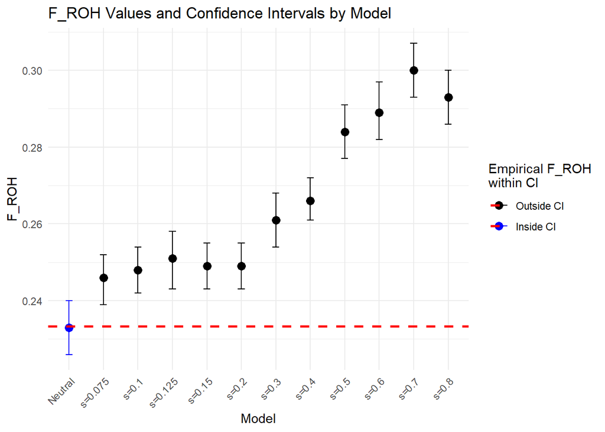

**Models the empirical $F_{ROH}$ is within the CI of:**

[1] “Neutral”

**Models the empirical $F_{ROH}$ is outside the CI of:**

[1] “s=0.075” “s=0.1” “s=0.125” “s=0.15” “s=0.2” “s=0.3” “s=0.4”  
[8] “s=0.5” “s=0.6” “s=0.7” “s=0.8”

| Model | F_ROH | Lower_CI | Upper_CI |
| --- | --- | --- | --- |
| Neutral | 0.233 | 0.226 | 0.240 |
| Empirical | 0.233 | NA | NA |
| s=0.075 | 0.246 | 0.239 | 0.252 |
| s=0.1 | 0.248 | 0.242 | 0.254 |
| s=0.15 | 0.249 | 0.243 | 0.255 |
| s=0.2 | 0.249 | 0.243 | 0.255 |
| s=0.125 | 0.251 | 0.243 | 0.258 |
| s=0.3 | 0.261 | 0.254 | 0.268 |
| s=0.4 | 0.266 | 0.261 | 0.272 |
| s=0.5 | 0.284 | 0.277 | 0.291 |
| s=0.6 | 0.289 | 0.282 | 0.297 |
| s=0.8 | 0.293 | 0.286 | 0.300 |
| s=0.7 | 0.300 | 0.293 | 0.307 |

## 6.2: Selection Testing of Empirical ROH Hotspots

### 6.2.1: Selection Test (Sweep Test)

This section shows the selection testing results of the different ROH hotspots based on the window average expected heterozygosity ($H_{e}$). The Table is sorted by expected heterozygosity in ascending order.

The threshold value for selection used in this selection test, comes from the lower boundary of the standard-error-based confidence interval for the 5th percentile extreme value of the neutral model simulations.

ROH-hotspot windows with a mean $H_{e}$ Value lower than or equal to the lower boundary of the confidence interval for the fifth percentile of the neutral model are classified as being under selection.

**The lower boundary of the standard-error-based confidence interval for the 5th percentile of the $H_{e}$-distribution for the neutral model is:**

0.16359

| Name | Under_selection | Window_based_Average_H_e |
| --- | --- | --- |
| hotspot_chr28_window_1 | Yes | 0.118 |
| hotspot_chr1_window_1 | Yes | 0.144 |
| hotspot_chr24_window_1 | No | 0.186 |
| hotspot_chr13_window_1 | No | 0.190 |
| hotspot_chr11_window_2 | No | 0.205 |
| hotspot_chr15_window_1 | No | 0.223 |
| hotspot_chr6_window_1 | No | 0.232 |
| hotspot_chr11_window_1 | No | 0.233 |
| hotspot_chr8_window_1 | No | 0.307 |

[1] “C:/Users/jonat/GitHub/roh-island-simulation/results_chr1_3185_Ne_50TC/Pipeline_results/ROH_hotspots_Selection_testing_neutral_model_H_E_threshold_0.164.csv.txt”

**ROH hotspots marked as candidate regions for selection:**

| Name | Under_selection | Window_based_Average_H_e |
| --- | --- | --- |
| hotspot_chr28_window_1 | Yes | 0.118 |
| hotspot_chr1_window_1 | Yes | 0.144 |

### (Optional) 6.2.2: Sweep Test of Causative Variant Windows

This optional “quality control” step verifies whether the Causative Variant Windows in the simulated selection models are accurately identified as candidate regions for selection based on the results of the sweep test.

[1] “C:/Users/jonat/GitHub/roh-island-simulation/results_chr1_3185_Ne_50TC/Pipeline_results/Causative_windows_under_selection.txt”

| Model | H_e | Lower_CI | Upper_CI | Under_Selection |
| --- | --- | --- | --- | --- |
| s=0.7 | 0.058 | 0.038 | 0.078 | Yes |
| s=0.6 | 0.063 | 0.046 | 0.081 | Yes |
| s=0.4 | 0.069 | 0.053 | 0.084 | Yes |
| s=0.5 | 0.084 | 0.058 | 0.110 | Yes |
| s=0.8 | 0.084 | 0.059 | 0.109 | Yes |
| s=0.3 | 0.086 | 0.066 | 0.105 | Yes |
| s=0.15 | 0.092 | 0.068 | 0.115 | Yes |
| s=0.2 | 0.093 | 0.072 | 0.114 | Yes |
| s=0.125 | 0.100 | 0.076 | 0.124 | Yes |
| s=0.075 | 0.112 | 0.091 | 0.133 | Yes |
| s=0.1 | 0.118 | 0.094 | 0.141 | Yes |
| Neutral | 0.167 | 0.164 | 0.171 | No |

## 6.3 Functional Assessment of Candidate Regions for Selection

### 6.3.1 Genes Identified in Candidate Regions

This section presents the results of the mapping of genes to the empirical ROH hotspot candidate region(s) for selection.

**The following gene annotation file was used to map genes to the empirical candidate region(s) for selection:**

roh-island-simulation/data/preprocessed/empirical/gene_annotations/canFam3.ncbiRefSeq.gtf.gz

**The tables below show the gene(s) overlapping with the following ROH hotspot candidate regions for selection, listed in order:** Hotspot_chr1_window_1, Hotspot_chr28_window_1 .

**Note:** The column ‘Overlap_Percentage’ represents the percentage of the gene that overlaps with the candidate region.

| CHR | POS1 | POS2 | Gene | Overlap_Percentage |
| --- | --- | --- | --- | --- |
| 1 | 21788833 | 22494849 | DCC | 84.25 |

| CHR | POS1 | POS2 | Gene | Overlap_Percentage |
| --- | --- | --- | --- | --- |
| 28 | 23966079 | 24162775 | TCF7L2 | 31.91 |
| 28 | 24167153 | 24178702 | LOC111093006 | 100.00 |
| 28 | 24228792 | 24234735 | LOC111093005 | 100.00 |
| 28 | 24235208 | 24244092 | LOC106557942 | 100.00 |
| 28 | 24245577 | 24246632 | LOC111093004 | 100.00 |
| 28 | 24427734 | 24431660 | LOC111093054 | 100.00 |
| 28 | 24489665 | 24522336 | HABP2 | 100.00 |
| 28 | 24522285 | 24592267 | NRAP | 100.00 |
| 28 | 24599866 | 24630018 | CASP7 | 100.00 |
| 28 | 24643803 | 24685947 | PLEKHS1 | 100.00 |
| 28 | 24704044 | 24724561 | DCLRE1A | 100.00 |
| 28 | 24724697 | 24782600 | NHLRC2 | 100.00 |
| 28 | 24749570 | 24907478 | LOC106557950 | 100.00 |
| 28 | 24905369 | 24906950 | LOC111092962 | 100.00 |
| 28 | 24908224 | 24909684 | ADRB1 | 100.00 |
| 28 | 24963035 | 25022996 | CCDC186 | 100.00 |
| 28 | 25026306 | 25028126 | LOC111093085 | 100.00 |
| 28 | 25028195 | 25081300 | TDRD1 | 100.00 |
| 28 | 25089499 | 25136879 | VWA2 | 100.00 |
| 28 | 25137235 | 25228454 | AFAP1L2 | 100.00 |
| 28 | 25178432 | 25184221 | LOC111093074 | 100.00 |
| 28 | 25260323 | 25543369 | ABLIM1 | 84.68 |

### 6.3.2 Non-Defect (Non-Disease-Related) Phenotypes Identified in Candidate Regions

This section presents the results of the search for known favorable/non-defect (non-disease-related) phenotypes from OMIA that overlap with the ROH hotspot candidate region(s) for selection.

The search was breed-specific and the Vertebrate Breed Ontology (VBO) IDs used were defined in the ‘vertebrate_breed_ontology_ids’ parameter of the main pipeline script.

**The following Vertebrate Breed Ontology (VBO) ID(s) were used to map phenotypes from OMIA with each candidate region for selection:** VBO_0200800, Unspecified

**The following OMIA phenotype file was used to map phenotypes to the empirical candidate region(s) for selection:**

C:/Users/jonat/GitHub/roh-island-simulation/data/preprocessed/empirical/omia_phenotype_data/All_dog_phenotypes.bed

**Result:**

No Non-Defect (Non-Disease-Related) phenotypes were discovered for the ROH hotspot candidate region(s) for selection

## 6.4: Selection Strength Estimation of Empirical ROH Hotspot Candidate Region(s) For Selection

In this section, the selection coefficients of empirical ROH-Hotspots, identified as candidate regions for selection, are estimated by comparing these regions with the Causative Variant Windows of the simulated selection models.

By identifying the selection model that produces Causative Variant Windows most similar to the empirical region in terms of:

– **ROH frequency**

– **Expected heterozygosity ($H_{e}$)**

– **Window length**

one can infer that the selection coefficient of the empirical candidate region likely corresponds to the selection coefficient of the matched selection model.

### 6.4.1: Comparison of ROH Hotspots and Causative Variant Windows

The following section compares the empirical ROH hotspot candidate region(s) for selection with the causative variant windows from the different selection models. The table is sorted by the selection strength of the models in descending alphanumerical order.

| Model | Lengths_Mb | Length_lower_ci | Length_upper_ci | ROH_Freq | ROH_freq_lower_ci | ROH_freq_upper_ci | H_e | H_e_lower_ci | H_e_upper_ci |
| --- | --- | --- | --- | --- | --- | --- | --- | --- | --- |
| s=0.8 | 2.58 | 2.19 | 2.96 | 96.1 | 93.3 | 98.9 | 0.084 | 0.059 | 0.109 |
| s=0.7 | 2.39 | 2.05 | 2.74 | 97.7 | 96.7 | 98.6 | 0.058 | 0.038 | 0.078 |
| s=0.6 | 2.06 | 1.79 | 2.33 | 96.2 | 94.4 | 98.0 | 0.063 | 0.046 | 0.081 |
| s=0.5 | 2.22 | 1.90 | 2.54 | 97.2 | 96.1 | 98.2 | 0.084 | 0.058 | 0.110 |
| s=0.4 | 1.96 | 1.67 | 2.25 | 93.5 | 90.7 | 96.2 | 0.069 | 0.053 | 0.084 |
| s=0.3 | 1.58 | 1.34 | 1.82 | 93.4 | 91.3 | 95.5 | 0.086 | 0.066 | 0.105 |
| s=0.2 | 1.41 | 1.17 | 1.64 | 87.3 | 83.8 | 90.7 | 0.093 | 0.072 | 0.114 |
| s=0.15 | 1.26 | 1.10 | 1.42 | 87.0 | 83.4 | 90.5 | 0.092 | 0.068 | 0.115 |
| s=0.125 | 1.11 | 0.96 | 1.26 | 82.2 | 77.2 | 87.3 | 0.100 | 0.076 | 0.124 |
| s=0.1 | 1.11 | 0.96 | 1.26 | 77.8 | 73.1 | 82.4 | 0.118 | 0.094 | 0.141 |
| s=0.075 | 1.04 | 0.92 | 1.16 | 77.1 | 72.7 | 81.5 | 0.112 | 0.091 | 0.133 |
| Hotspot_chr28_window_1 | 1.40 | NA | NA | 75.0 | NA | NA | 0.118 | NA | NA |
| Hotspot_chr1_window_1 | 0.70 | NA | NA | 56.2 | NA | NA | 0.144 | NA | NA |

### 6.4.2: 3D Plot Comparison of Mean Values

This section presents a 3D-scatterplot comparing the ROH hotspot candidate region(s) for selection in the empirical dataset with the causative variant windows from different selection models (displayed in monochromatic color). The axes are defined as follows:

- **x-axis:** Represents the average ROH frequency of 100 kbp windows in the respective regions (percentage).
- **y-axis:** Represents the average $H_{e}$ of 100 kbp windows in the respective regions.
- **z-axis:** Represents the average length of the respective regions (in megabases).

To enhance the readability of the plots have vertical lines been added for each data point, projecting the regions onto the x-y plane.

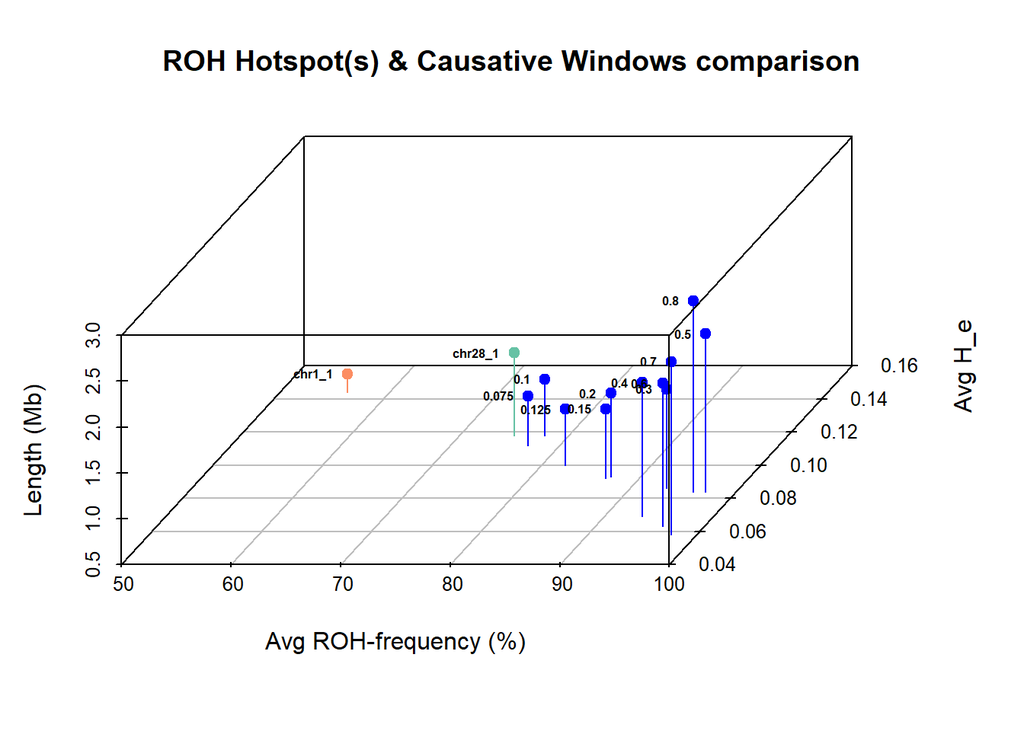

### 6.4.3: Visualization of Confidence Intervals and Means

In this section, plots of the standard error-based confidence intervals, alongside mean values, are created to account for the distribution of values, rather than relying solely on the mean (as is the case in the 3D-plot).

These plots are generated individually for each empirical candidate region for selection, allowing a more detailed comparison between each empirical ROH Hotspot and the Causative Variant Windows of the simulated selection models.

#### 6.4.3.1: Standard Error CI for $H_{e}$

The following section displays plot(s) comparing the average expected heterozygosity of the empirical ROH Hotspot(s) with the corresponding standard error-based confidence intervals for the different causative variant windows.

**Models whose confidence intervals contain the empirical $H_{e}$ for Hotspot_chr28_window_1 :**

[1] “s=0.075” “s=0.1” “s=0.125”

**Models in which the empirical $H_{e}$, for Hotspot_chr28_window_1 , falls outside the confidence interval:**

[1] “s=0.15” “s=0.2” “s=0.3” “s=0.4” “s=0.5” “s=0.6” “s=0.7” “s=0.8”

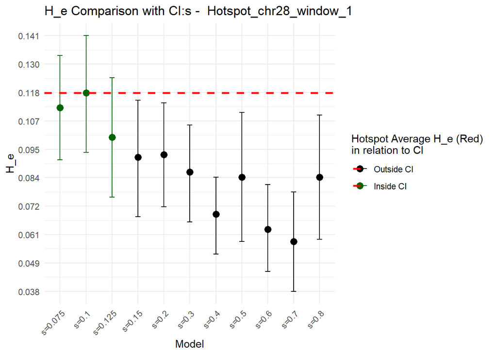

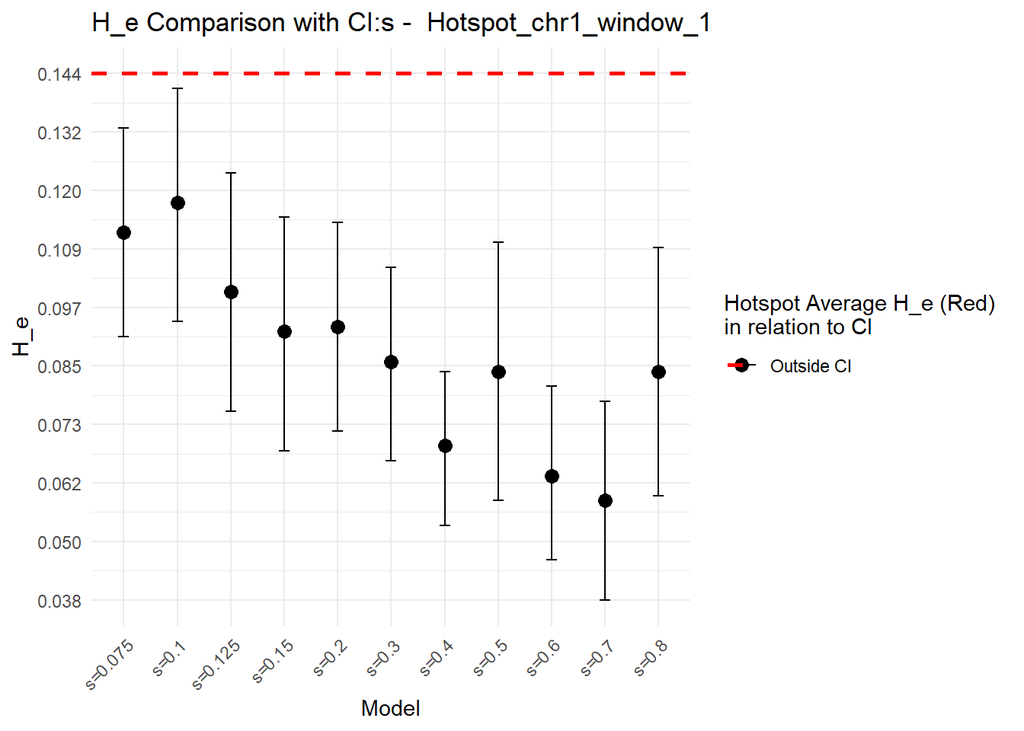

**Models whose confidence intervals contain the empirical $H_{e}$ for Hotspot_chr1_window_1 :**

No models had confidence intervals containing the empirical $H_{e}$.

**Models in which the empirical $H_{e}$, for Hotspot_chr1_window_1 , falls outside the confidence interval:**

[1] “s=0.075” “s=0.1” “s=0.125” “s=0.15” “s=0.2” “s=0.3” “s=0.4”  
[8] “s=0.5” “s=0.6” “s=0.7” “s=0.8”

#### 6.4.3.2: Standard Error CI for Window Length

The following section displays plot(s) comparing the average Window length of the empirical ROH hotspot(s) with the corresponding standard error-based confidence intervals for the different causative variant windows.

**Models whose confidence intervals contain the empirical window length for Hotspot_chr28_window_1 :**

[1] “s=0.15” “s=0.2” “s=0.3”

**Models in which the empirical window length, for Hotspot_chr28_window_1 , falls outside the confidence interval:**

[1] “s=0.075” “s=0.1” “s=0.125” “s=0.4” “s=0.5” “s=0.6” “s=0.7”  
[8] “s=0.8”

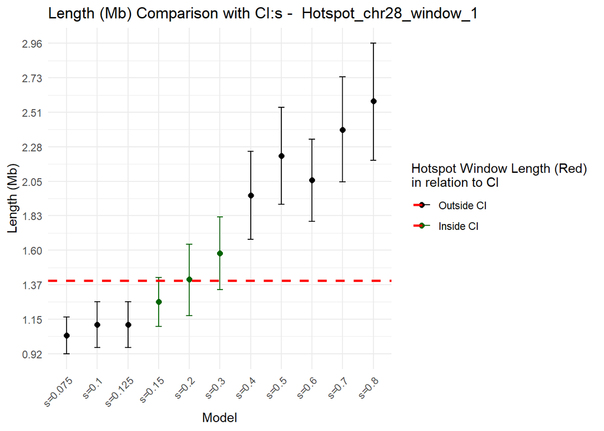

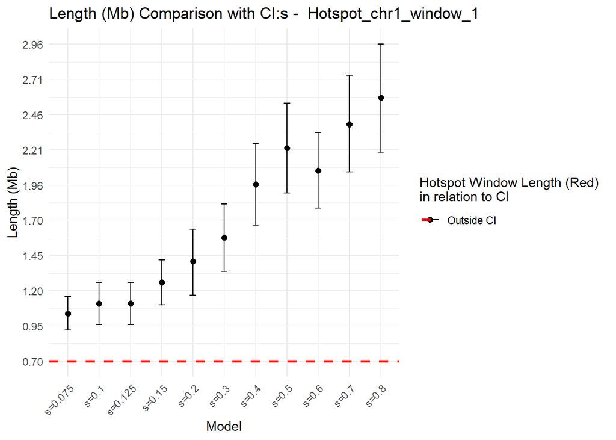

**Models whose confidence intervals contain the empirical window length for Hotspot_chr1_window_1 :**

No models had confidence intervals containing the empirical window length.

**Models in which the empirical window length, for Hotspot_chr1_window_1 , falls outside the confidence interval:**

[1] “s=0.075” “s=0.1” “s=0.125” “s=0.15” “s=0.2” “s=0.3” “s=0.4”  
[8] “s=0.5” “s=0.6” “s=0.7” “s=0.8”

#### 6.4.3.3: Standard Error CI for ROH Frequency

The following section displays plot(s) comparing the average ROH-frequency of the empirical ROH hotspot(s) with the corresponding standard error-based confidence intervals for the different causative variant windows.

**Models whose confidence intervals contain the empirical ROH frequency for Hotspot_chr28_window_1 :**

[1] “s=0.075” “s=0.1”

**Models in which the empirical ROH frequency, for Hotspot_chr28_window_1 , falls outside the confidence interval:**

[1] “s=0.125” “s=0.15” “s=0.2” “s=0.3” “s=0.4” “s=0.5” “s=0.6”  
[8] “s=0.7” “s=0.8”

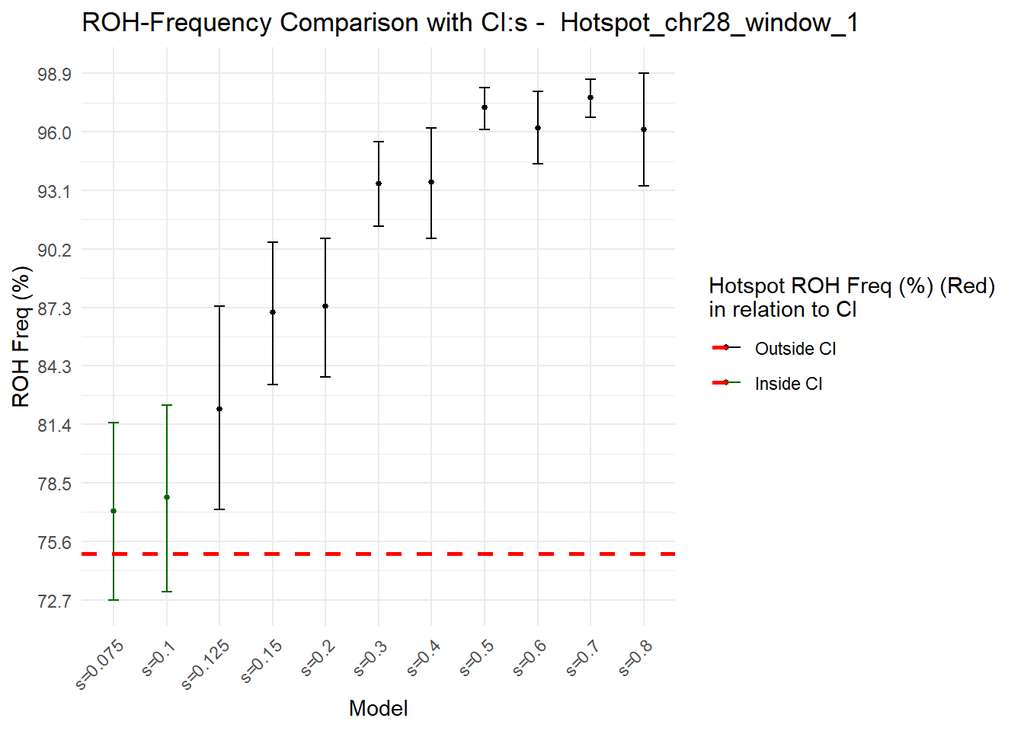

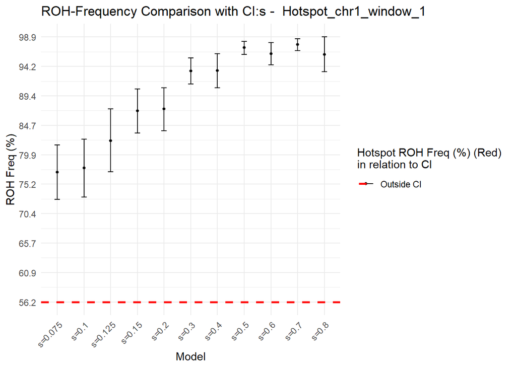

**Models whose confidence intervals contain the empirical ROH frequency for Hotspot_chr1_window_1 :**

No models had confidence intervals containing the empirical ROH frequency.

**Models in which the empirical ROH frequency, for Hotspot_chr1_window_1 , falls outside the confidence interval:**

[1] “s=0.075” “s=0.1” “s=0.125” “s=0.15” “s=0.2” “s=0.3” “s=0.4”  
[8] “s=0.5” “s=0.6” “s=0.7” “s=0.8”